# Full report on dataset

Autogenerated data summary from dataMaid

2020-09-02 20:50:09

# Data report overview

The dataset examined has the following dimensions:

| Feature | Result |
| --- | --- |
| Number of observations | 4898 |
| Number of variables | 12 |

### Checks performed

The following variable checks were performed, depending on the data type of each variable:

|  | character | factor | labelled | haven labelled | numeric | integer | logical | Date |
| --- | --- | --- | --- | --- | --- | --- | --- | --- |
| Identify miscoded missing values | × | × | × | × | × | × |  | × |
| Identify prefixed and suffixed whitespace | × | × | × | × |  |  |  |  |
| Identify levels with < 6 obs. | × | × | × | × |  |  |  |  |
| Identify case issues | × | × | × | × |  |  |  |  |
| Identify misclassified numeric or integer variables | × | × | × | × |  |  |  |  |
| Identify outliers |  |  |  |  | × | × |  | × |

Please note that all numerical values in the following have been rounded to 2 decimals.

# Summary table

|  | Variable class | # unique values | Missing observations | Any problems? |
| --- | --- | --- | --- | --- |
| fixed.acidity | numeric | 68 | 0.00 % | × |
| volatile.acidity | numeric | 125 | 0.00 % | × |
| citric.acid | numeric | 87 | 0.00 % | × |
| residual.sugar | numeric | 310 | 0.00 % | × |
| chlorides | numeric | 160 | 0.00 % | × |
| free.sulfur.dioxide | numeric | 132 | 0.00 % | × |
| total.sulfur.dioxide | numeric | 251 | 0.00 % | × |
| density | numeric | 890 | 0.00 % | × |
| pH | numeric | 103 | 0.00 % | × |
| sulphates | numeric | 79 | 0.00 % | × |
| alcohol | numeric | 103 | 0.00 % |  |
| quality | integer | 7 | 0.00 % | × |

# Variable list

## fixed.acidity

| Feature | Result |
| --- | --- |
| Variable type | numeric |
| Number of missing obs. | 0 (0 %) |
| Number of unique values | 68 |
| Median | 6.8 |
| 1st and 3rd quartiles | 6.3; 7.3 |
| Min. and max. | 3.8; 14.2 |

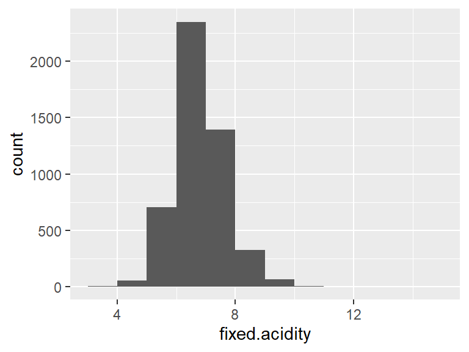

- Note that the following possible outlier values were detected: "3.8", "3.9", "4.2", "4.4", "4.5", "4.6", "4.7", "4.8", "4.9", "5" (15 additional values omitted).

## volatile.acidity

| Feature | Result |
| --- | --- |
| Variable type | numeric |
| Number of missing obs. | 0 (0 %) |
| Number of unique values | 125 |
| Median | 0.26 |
| 1st and 3rd quartiles | 0.21; 0.32 |
| Min. and max. | 0.08; 1.1 |

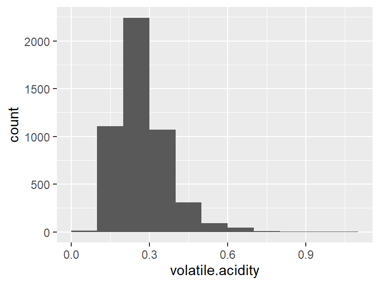

- Note that the following possible outlier values were detected: "0.08", "0.08", "0.09", "0.1", "0.1", "0.11", "0.12", "0.58", "0.58", "0.59" (31 additional values omitted).

## citric.acid

| Feature | Result |
| --- | --- |
| Variable type | numeric |
| Number of missing obs. | 0 (0 %) |
| Number of unique values | 87 |
| Median | 0.32 |
| 1st and 3rd quartiles | 0.27; 0.39 |
| Min. and max. | 0; 1.66 |

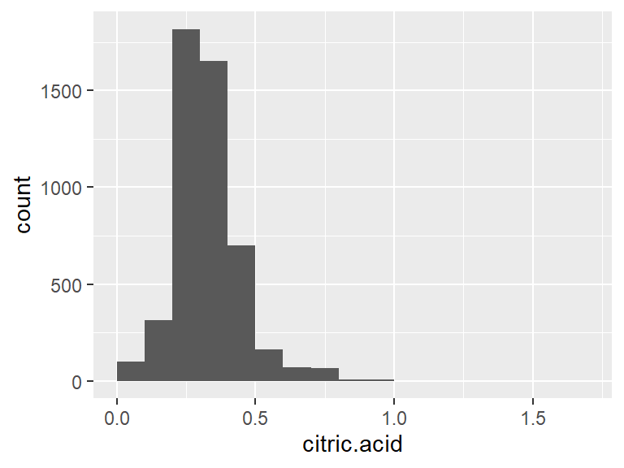

- Note that the following possible outlier values were detected: "0", "0.01", "0.02", "0.03", "0.04", "0.05", "0.06", "0.07", "0.08", "0.09" (26 additional values omitted).

## residual.sugar

| Feature | Result |
| --- | --- |
| Variable type | numeric |
| Number of missing obs. | 0 (0 %) |
| Number of unique values | 310 |
| Median | 5.2 |
| 1st and 3rd quartiles | 1.7; 9.9 |
| Min. and max. | 0.6; 65.8 |

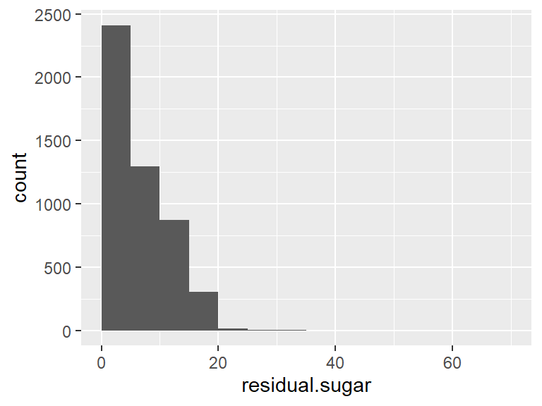

- Note that the following possible outlier values were detected: "65.8".

## chlorides

| Feature | Result |
| --- | --- |
| Variable type | numeric |
| Number of missing obs. | 0 (0 %) |
| Number of unique values | 160 |
| Median | 0.04 |
| 1st and 3rd quartiles | 0.04; 0.05 |
| Min. and max. | 0.01; 0.35 |

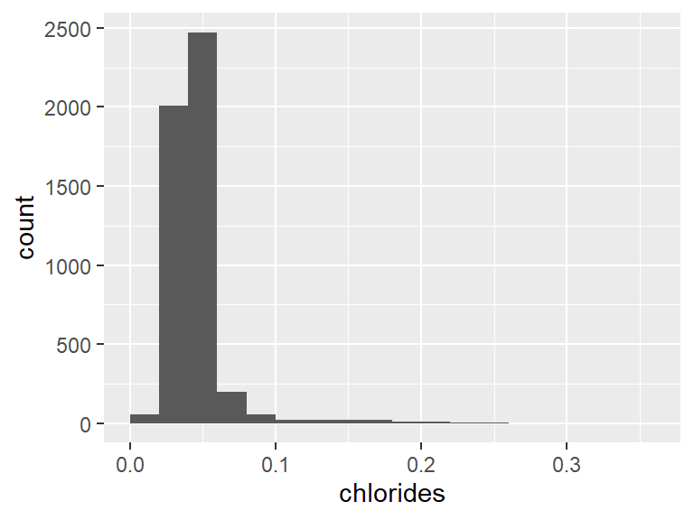

- Note that the following possible outlier values were detected: "0.01", "0.01", "0.01", "0.01", "0.02", "0.07", "0.07", "0.07", "0.08", "0.08" (94 additional values omitted).

## free.sulfur.dioxide

| Feature | Result |
| --- | --- |
| Variable type | numeric |
| Number of missing obs. | 0 (0 %) |
| Number of unique values | 132 |
| Median | 34 |
| 1st and 3rd quartiles | 23; 46 |
| Min. and max. | 2; 289 |

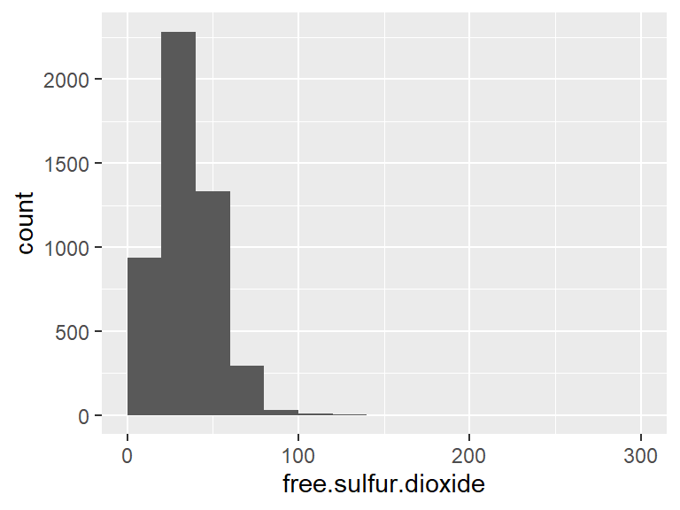

- Note that the following possible outlier values were detected: "89", "93", "95", "96", "97", "98", "101", "105", "108", "110" (9 additional values omitted).

## total.sulfur.dioxide

| Feature | Result |
| --- | --- |
| Variable type | numeric |
| Number of missing obs. | 0 (0 %) |
| Number of unique values | 251 |
| Median | 134 |
| 1st and 3rd quartiles | 108; 167 |
| Min. and max. | 9; 440 |

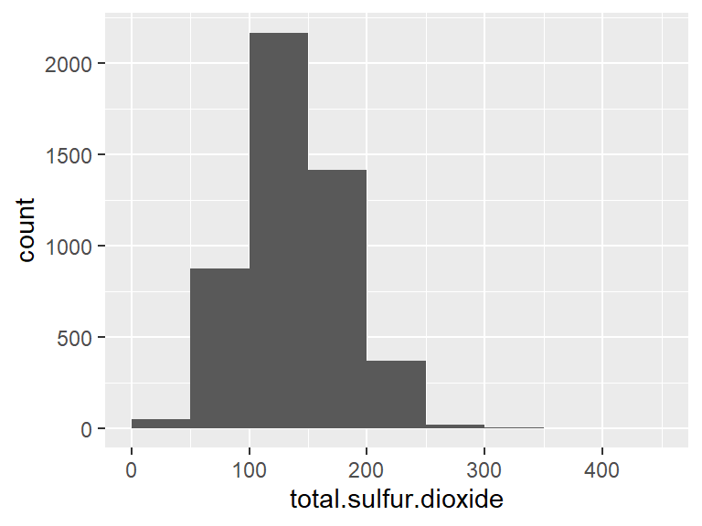

- Note that the following possible outlier values were detected: "9", "10", "18", "19", "21", "24", "25", "26", "28", "29" (23 additional values omitted).

## density

| Feature | Result |
| --- | --- |
| Variable type | numeric |
| Number of missing obs. | 0 (0 %) |
| Number of unique values | 890 |
| Median | 0.99 |
| 1st and 3rd quartiles | 0.99; 1 |
| Min. and max. | 0.99; 1.04 |

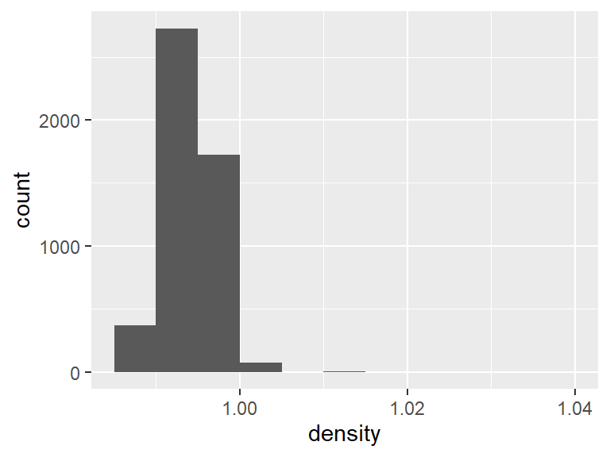

- Note that the following possible outlier values were detected: "0.99", "0.99", "0.99", "0.99", "1.01", "1.04".

## pH

| Feature | Result |
| --- | --- |
| Variable type | numeric |
| Number of missing obs. | 0 (0 %) |
| Number of unique values | 103 |
| Median | 3.18 |
| 1st and 3rd quartiles | 3.09; 3.28 |
| Min. and max. | 2.72; 3.82 |

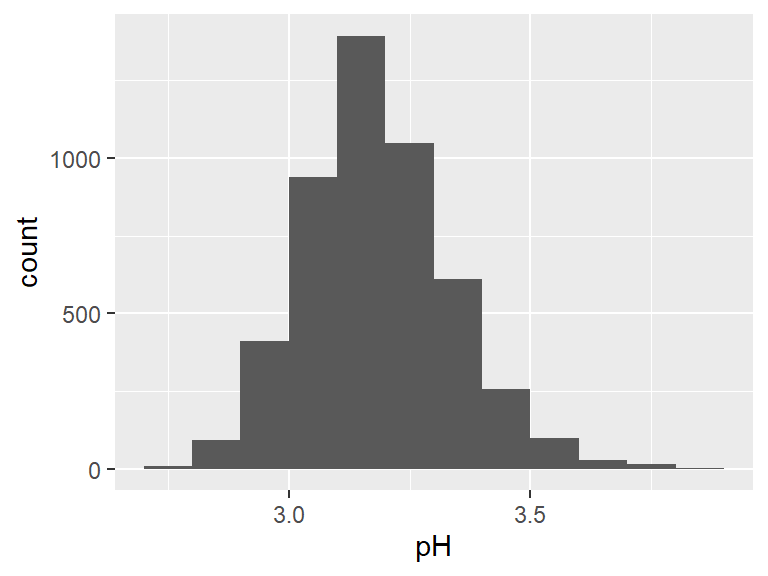

- Note that the following possible outlier values were detected: "2.72", "2.74", "2.77", "2.79", "2.8", "2.82", "2.83", "2.84", "2.85", "2.86" (17 additional values omitted).

## sulphates

| Feature | Result |
| --- | --- |
| Variable type | numeric |
| Number of missing obs. | 0 (0 %) |
| Number of unique values | 79 |
| Median | 0.47 |
| 1st and 3rd quartiles | 0.41; 0.55 |
| Min. and max. | 0.22; 1.08 |

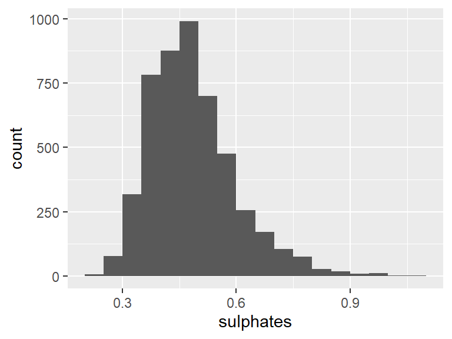

- Note that the following possible outlier values were detected: "0.22", "0.23", "0.25", "0.26", "0.27", "0.28", "0.29", "0.88", "0.89", "0.9" (11 additional values omitted).

## alcohol

| Feature | Result |
| --- | --- |
| Variable type | numeric |
| Number of missing obs. | 0 (0 %) |
| Number of unique values | 103 |
| Median | 10.4 |
| 1st and 3rd quartiles | 9.5; 11.4 |
| Min. and max. | 8; 14.2 |

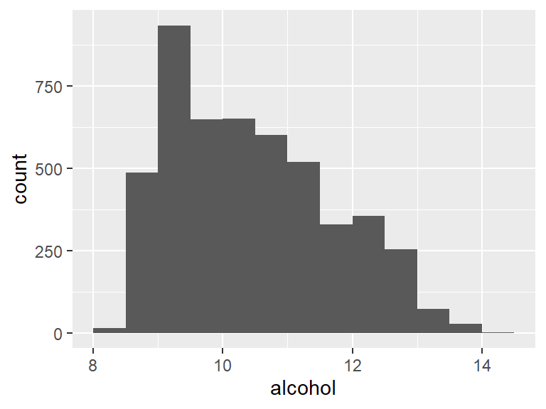

## quality

| Feature | Result |
| --- | --- |
| Variable type | integer |
| Number of missing obs. | 0 (0 %) |
| Number of unique values | 7 |
| Median | 6 |
| 1st and 3rd quartiles | 5; 6 |
| Min. and max. | 3; 9 |

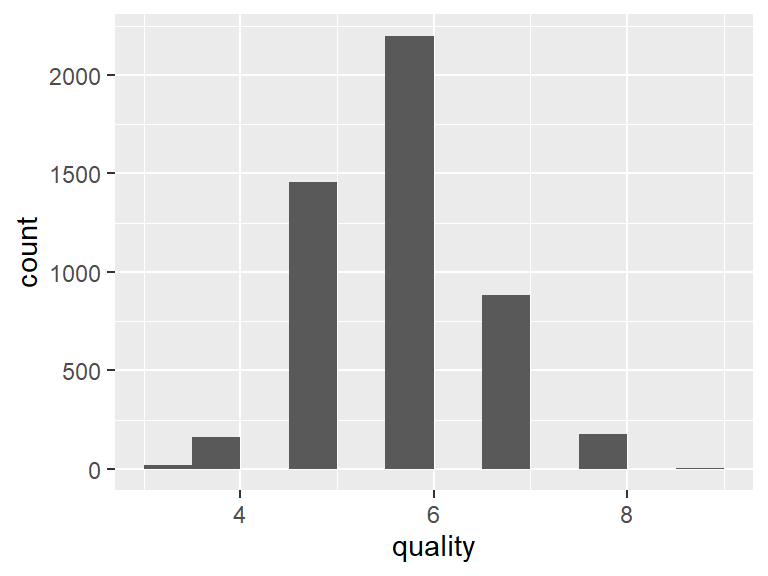

- Note that the following possible outlier values were detected: "3", "8", "9".

Report generation information:

- Created by: UrosG (username: `urosg`).
- Report creation time: sre. sep. 02 2020 20:50:10
- Report was run from directory: `C:/Users/urosg/OneDrive/Famnit/Machine learning with R and Python`
- dataMaid v1.4.0 [Pkg: 2019-12-10 from CRAN (R 3.6.3)]
- R version 3.6.2 (2019-12-12).
- Platform: x86_64-w64-mingw32/x64 (64-bit)(Windows 10 x64 (build 19041)).
- Function call: `makeDataReport(data = data, output = "html", render = TRUE, file = "FullReport.html", replace = TRUE, reportTitle = "Full report on dataset")`